# *Análisis del Dataset del Titanic - Modelo de Clasificación*

# *Autor: Carlos Mario Vergara Estremor*

# *Fecha: 17/03/2025*

# Procedemos a la Importación de librerías necesarias

```python
import numpy as np
import pandas as pd
import matplotlib.pyplot as plt
import seaborn as sns
from sklearn.model_selection import train_test_split,GridSearchCV, cross_val_score, StratifiedKFold
from sklearn.preprocessing import StandardScaler, OneHotEncoder
from sklearn.impute import SimpleImputer
from sklearn.compose import ColumnTransformer
from sklearn.pipeline import Pipeline
from sklearn.metrics import accuracy_score, classification_report, confusion_matrix, roc_curve, auc
from sklearn.linear_model import LogisticRegression
from sklearn.tree import DecisionTreeClassifier
from sklearn.ensemble import RandomForestClassifier,GradientBoostingClassifier
from sklearn.svm import SVC
import warnings
warnings.filterwarnings('ignore')
```

# Configuración de visualización

```python
plt.style.use('seaborn-v0_8-whitegrid')
sns.set(font_scale=1.2)
pd.set_option('display.max_columns', None)
```

###########################################

# 1. SELECCIÓN DE LA BASE DE DATOS Y PLANTEAMIENTO DEL PROBLEMA

###########################################

**Variables del dataset Titanic:**

- PassengerId: Número único de identificación asignado a cada pasajero.
- Survived: Variable objetivo (**target**) que indica si el pasajero sobrevivió (1) o no (0).
- Pclass: Clase del ticket (1 = Primera clase, 2 = Segunda clase, 3 = Tercera clase). Tomado como un indicador del estatus socioeconómico.
- Name: Nombre completo del pasajero.
- Sex: Género del pasajero (male/female).
- Age: Edad del pasajero en años. Contiene valores faltantes.
- SibSp: Número de hermanos/cónyuges a bordo del Titanic.
- Parch: Número de padres/hijos a bordo del Titanic.
- Ticket: Número de ticket.
- Fare: Tarifa pagada por el pasajero.
- Cabin: Número de cabina.
- Embarked: Puerto de embarque (C = Cherbourg, Q = Queenstown, S = Southampton).

```python
# Carga de datasets
train_data = pd.read_csv('train.csv')
test_data = pd.read_csv('test.csv')
gender_submission = pd.read_csv('gender_submission.csv')

print("Dimensiones del conjunto de entrenamiento:", train_data.shape)
print("Dimensiones del conjunto de prueba:", test_data.shape)
```

```
Dimensiones del conjunto de entrenamiento: (891, 12)
Dimensiones del conjunto de prueba: (418, 11)
```

**A continuación en el ejercicio tendremos que aplicar un merge para unir el conjunto de prueba con las etiquetas de gender_submission para un análisis completo**.

```python
test_data_with_target = test_data.merge(gender_submission, on='PassengerId')

# Combinamos train y test para algunas visualizaciones
train_data['Set'] = 'Train'
test_data_with_target['Set'] = 'Test'
full_data = pd.concat([train_data, test_data_with_target], axis=0)
```

```python
# Descripción del problema y objetivo
print("\nObjetivo: Predecir si un pasajero del Titanic sobrevivió (1) o no (0) al hundimiento.")
print("Contexto: El hundimiento del RMS Titanic en 1912 fue una de las tragedias marítimas más famosas de la historia.")
print("Este modelo permitirá identificar patrones socioeconómicos y comportamentales que influyeron en la supervivencia durante este desastre.")
```

```
Objetivo: Predecir si un pasajero del Titanic sobrevivió (1) o no (0) al hundimiento.
Contexto: El hundimiento del RMS Titanic en 1912 fue una de las tragedias marítimas más famosas de la historia.
Este modelo permitirá identificar patrones socioeconómicos y comportamentales que influyeron en la supervivencia durante este desastre.
```

###########################################

# 2. EXPLORACIÓN, LIMPIEZA Y PREPARACIÓN DE LOS DATOS

###########################################

```python
print("\n--- INFORMACIÓN GENERAL DEL DATASET ---")
print(train_data.info())

print("\n--- PRIMERAS FILAS DEL DATASET ---")
print(train_data.head())

print("\n--- ESTADÍSTICAS DESCRIPTIVAS ---")
print(train_data.describe())

print("\n--- VALORES FALTANTES POR COLUMNA ---")
missing_values = train_data.isnull().sum()
missing_percent = (missing_values / len(train_data)) * 100
missing_data = pd.concat([missing_values, missing_percent], axis=1)
missing_data.columns = ['Valores Faltantes', 'Porcentaje']
print(missing_data[missing_data['Valores Faltantes'] > 0].sort_values('Porcentaje', ascending=False))
```

```
--- INFORMACIÓN GENERAL DEL DATASET ---
<class 'pandas.core.frame.DataFrame'>
RangeIndex: 891 entries, 0 to 890
Data columns (total 13 columns):
 #   Column       Non-Null Count  Dtype
---  ------       --------------  -----
 0   PassengerId  891 non-null    int64
 1   Survived     891 non-null    int64
 2   Pclass       891 non-null    int64
 3   Name         891 non-null    object
 4   Sex          891 non-null    object
 5   Age          714 non-null    float64
 6   SibSp        891 non-null    int64
 7   Parch        891 non-null    int64
 8   Ticket       891 non-null    object
 9   Fare         891 non-null    float64
 10  Cabin        204 non-null    object
 11  Embarked     889 non-null    object
 12  Set          891 non-null    object
dtypes: float64(2), int64(5), object(6)
memory usage: 90.6+ KB
None

--- PRIMERAS FILAS DEL DATASET ---
   PassengerId  Survived  Pclass  \
0            1         0       3
1            2         1       1
2            3         1       3
3            4         1       1
4            5         0       3

                                                Name     Sex   Age  SibSp  \
0                            Braund, Mr. Owen Harris    male  22.0      1
1  Cumings, Mrs. John Bradley (Florence Briggs Th...  female  38.0      1
2                             Heikkinen, Miss. Laina  female  26.0      0
3       Futrelle, Mrs. Jacques Heath (Lily May Peel)  female  35.0      1
4                           Allen, Mr. William Henry    male  35.0      0

   Parch            Ticket     Fare Cabin Embarked    Set
0      0         A/5 21171   7.2500   NaN        S  Train
```

[output cut: 16 more lines]

```
            Parch        Fare
count  891.000000  891.000000
mean     0.381594   32.204208
std      0.806057   49.693429
min      0.000000    0.000000
25%      0.000000    7.910400
50%      0.000000   14.454200
75%      0.000000   31.000000
max      6.000000  512.329200

--- VALORES FALTANTES POR COLUMNA ---
          Valores Faltantes  Porcentaje
Cabin                   687   77.104377
Age                     177   19.865320
Embarked                  2    0.224467
```

**Puntuación importante**: Siguiendo el comportamiento de la información general del dataset, se denota como faltan algunos datos en 'edad' y 'Embarque', destaco por su importación en la construcción de los modelos a evaluar más adelante.

- Se hace la debida observación en las estadisticas descriptivas, donde en edad la media de los que se encontraban en la embarcación es 29 y la desviación que es de 14.52,que se clasifica como alta con respecto a su media, la edad máxima registrada es 80, más adelante deducieremos cosas interesantes.
- Con respecto a la tarifa de embarque podemos ver que la clase alta llegó a pagar 512 pounds por su derecho a embarque siendo la más alta en el Titanic, se encuentra una gran brecha con respecto a la media marcando así unos 32 pounds.
- Ahora analisando el porcentaje de datos faltantes vemos que la edad presente una perdida de 19.86% de los mismos pero siempre distante a lo registrado por la puerta de embarque de no más de 0.2% .

# Análisis de distribución de la variable objetivo

```python
print("\n--- DISTRIBUCIÓN DE SUPERVIVENCIA ---")
survival_counts = train_data['Survived'].value_counts()
print(survival_counts)
print(f"Porcentaje de sobrevivientes: {survival_counts[1]/len(train_data)*100:.2f}%")
print(f"Porcentaje de fallecidos: {survival_counts[0]/len(train_data)*100:.2f}%")
```

```
--- DISTRIBUCIÓN DE SUPERVIVENCIA ---
Survived
0    549
1    342
Name: count, dtype: int64
Porcentaje de sobrevivientes: 38.38%
Porcentaje de fallecidos: 61.62%
```

**Este paso radica la importancia de ver como van distribuidos el rubro de casos de personas que fallecieron y cómo influira en las predicciones de los modelos.**

- **Se hace evidente la importancia porcentual de los fallecidos siendo al rededor de 2/3 partes de la cantidad de los pasajeros en el Titanic, más adelante veremos en como radicó ese registro.**

# Limpieza de datos y tratamiento de valores faltantes

```python
# 1. Extracción de títulos de nombres
def extract_title(name):
    return name.split(',')[1].split('.')[0].strip()

train_data['Title'] = train_data['Name'].apply(extract_title)
test_data['Title'] = test_data['Name'].apply(extract_title)

# Agrupar títulos menos comunes
rare_titles = ['Dona', 'Lady', 'Countess','Capt', 'Col', 'Don', 'Dr', 'Major', 'Rev', 'Sir', 'Jonkheer']

train_data['Title'] = train_data['Title'].replace(rare_titles, 'Rare')
train_data['Title'] = train_data['Title'].replace(['Mlle', 'Ms'], 'Miss')
train_data['Title'] = train_data['Title'].replace('Mme', 'Mrs')

test_data['Title'] = test_data['Title'].replace(rare_titles, 'Rare')
test_data['Title'] = test_data['Title'].replace(['Mlle', 'Ms'], 'Miss')
test_data['Title'] = test_data['Title'].replace('Mme', 'Mrs')
```

```python
# 2. Creación de características de familia
train_data['FamilySize'] = train_data['SibSp'] + train_data['Parch'] + 1
test_data['FamilySize'] = test_data['SibSp'] + test_data['Parch'] + 1

train_data['IsAlone'] = (train_data['FamilySize'] == 1).astype(int)
test_data['IsAlone'] = (test_data['FamilySize'] == 1).astype(int)
```

```python
# 3. Llenado de valores faltantes

title_age_median = train_data.groupby('Title')['Age'].median()

for dataset in [train_data, test_data]:
    for title in title_age_median.index:
        dataset.loc[(dataset['Age'].isnull()) & (dataset['Title'] == title), 'Age'] = title_age_median[title]


most_common_embarked = train_data['Embarked'].mode()[0]
train_data['Embarked'] = train_data['Embarked'].fillna(most_common_embarked)
```

- *Para Age, usamos la mediana por título*.
- *Para Embarked, usamos el valor más común. Esto nos agilizará el proceso.*

```python
# Para Fare en test, usamos la mediana por clase
median_fare = test_data.groupby('Pclass')['Fare'].median()
for pclass in median_fare.index:
    test_data.loc[(test_data['Fare'].isnull()) & (test_data['Pclass'] == pclass), 'Fare'] = median_fare[pclass]
```

```python
# 4. Creación de bandas de edad
def create_age_bands(df):
    df['AgeBand'] = pd.cut(df['Age'], bins=[0, 12, 18, 35, 60, 100], labels=['Child', 'Teenager', 'Young Adult', 'Adult', 'Senior'])
    return df

train_data = create_age_bands(train_data)
test_data = create_age_bands(test_data)
```

```python
# 5. Creación de bandas de tarifa
def create_fare_bands(df):
    df['FareBand'] = pd.qcut(df['Fare'], 4, labels=['Low', 'Medium', 'High', 'Very High'])
    return df

train_data = create_fare_bands(train_data)
test_data = create_fare_bands(test_data)
```

```python
# 6. Conversión de variables categóricas a numéricas
for dataset in [train_data, test_data]:
    # Sexo
    dataset['Sex'] = dataset['Sex'].map({'male': 0, 'female': 1})

    # Embarked
    dataset['Embarked'] = dataset['Embarked'].map({'S': 0, 'C': 1, 'Q': 2})

    # Título
    title_mapping = {'Mr': 0, 'Miss': 1, 'Mrs': 2, 'Master': 3, 'Rare': 4}
    dataset['Title'] = dataset['Title'].map(title_mapping)

print("\n--- VERIFICACIÓN DE DATOS DESPUÉS DE LIMPIEZA ---")
print(train_data.isnull().sum())
```

```
--- VERIFICACIÓN DE DATOS DESPUÉS DE LIMPIEZA ---
PassengerId      0
Survived         0
Pclass           0
Name             0
Sex              0
Age              0
SibSp            0
Parch            0
Ticket           0
Fare             0
Cabin          687
Embarked         0
Set              0
Title            1
FamilySize       0
IsAlone          0
AgeBand          0
FareBand         0
dtype: int64
```

- *Ahora nuestro dataset se le realizaron los procedimentos pertinentes y mencionados anteriormente para poder trabajar y construir modelos de machine learning de la mejor manera*.

###########################################

# 3. ESTADÍSTICA BÁSICA Y ANÁLISIS PRELIMINAR

###########################################

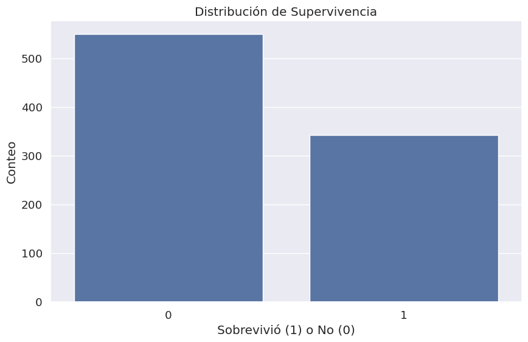

```python
# Exploración de relaciones entre variables y supervivencia
plt.figure(figsize=(10, 6))
sns.countplot(x='Survived', data=train_data)
plt.title('Distribución de Supervivencia')
plt.xlabel('Sobrevivió (1) o No (0)')
plt.ylabel('Conteo')
plt.savefig('supervivencia_distribucion.png')
```

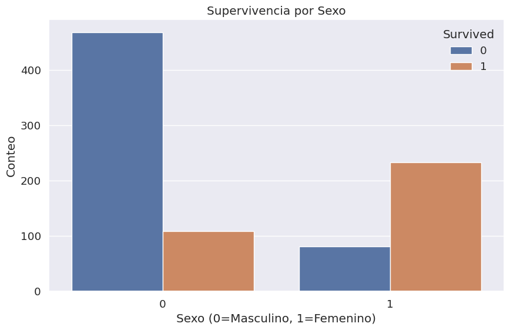

```python
# Supervivencia por Sexo
plt.figure(figsize=(10, 6))
sns.countplot(x='Sex', hue='Survived', data=train_data)
plt.title('Supervivencia por Sexo')
plt.xlabel('Sexo (0=Masculino, 1=Femenino)')
plt.ylabel('Conteo')
plt.savefig('supervivencia_por_sexo.png')
```

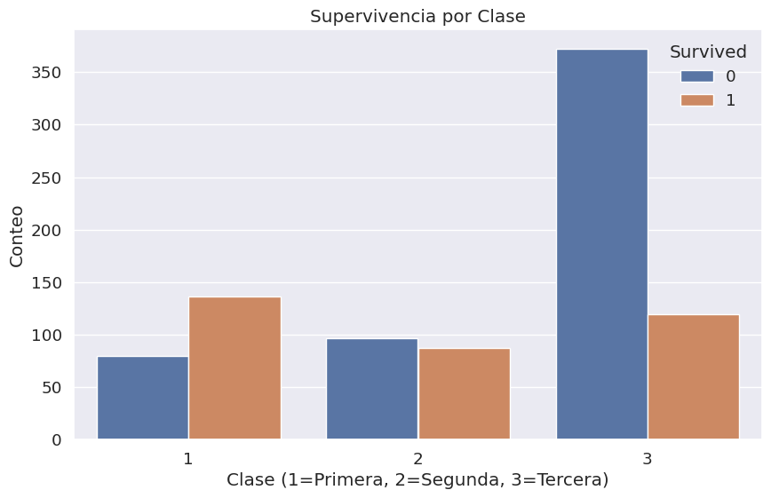

```python
# Supervivencia por Clase
plt.figure(figsize=(10, 6))
sns.countplot(x='Pclass', hue='Survived', data=train_data)
plt.title('Supervivencia por Clase')
plt.xlabel('Clase (1=Primera, 2=Segunda, 3=Tercera)')
plt.ylabel('Conteo')
plt.savefig('supervivencia_por_clase.png')
```

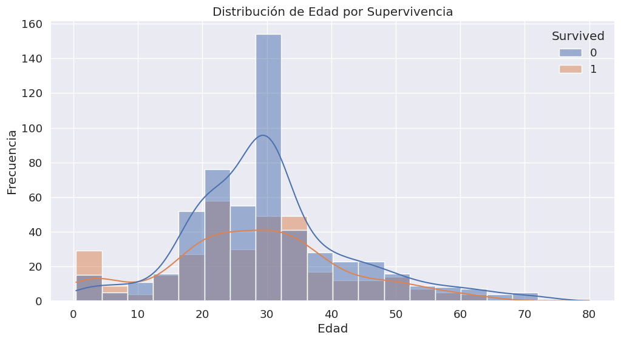

```python
# Distribución de Edad
plt.figure(figsize=(12, 6))
sns.histplot(data=train_data, x='Age', hue='Survived', bins=20, kde=True)
plt.title('Distribución de Edad por Supervivencia')
plt.xlabel('Edad')
plt.ylabel('Frecuencia')
plt.savefig('edad_distribucion.png')
```

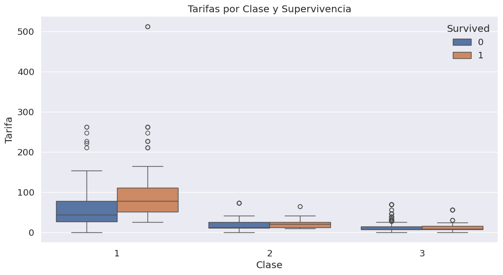

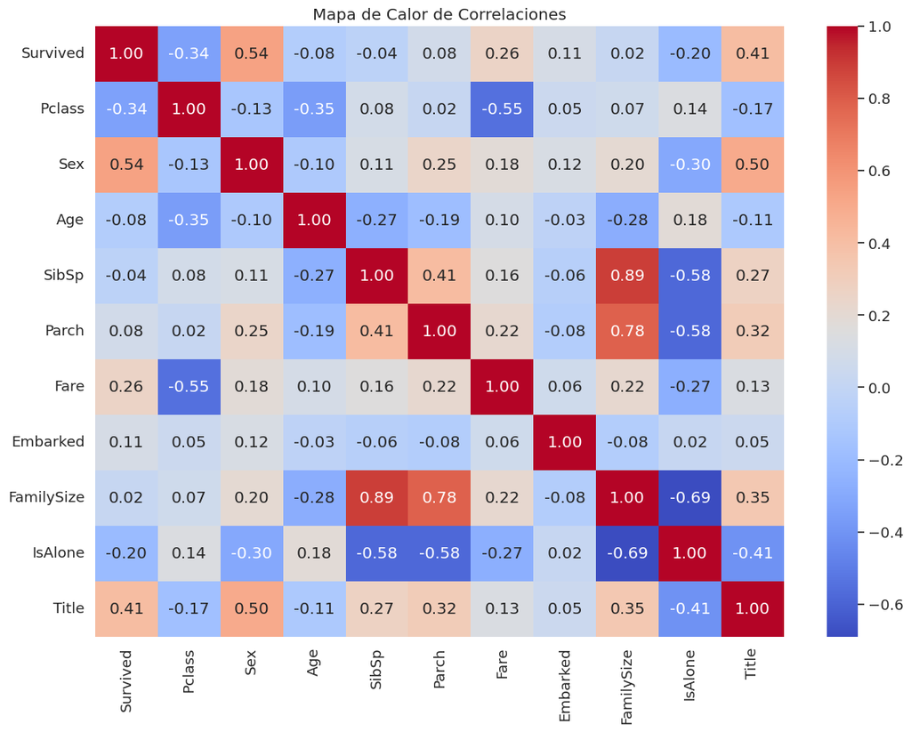

```python
# Tarifas por Clase y Supervivencia
plt.figure(figsize=(12, 6))
sns.boxplot(x='Pclass', y='Fare', hue='Survived', data=train_data)
plt.title('Tarifas por Clase y Supervivencia')
plt.xlabel('Clase')
plt.ylabel('Tarifa')
plt.savefig('tarifas_por_clase.png')


# Mapa de calor de correlaciones
plt.figure(figsize=(14, 10))
correlation_matrix = train_data[['Survived', 'Pclass', 'Sex', 'Age', 'SibSp', 'Parch', 'Fare', 'Embarked', 'FamilySize', 'IsAlone', 'Title']].corr()
sns.heatmap(correlation_matrix, annot=True, cmap='coolwarm', fmt='.2f')
plt.title('Mapa de Calor de Correlaciones')
plt.savefig('correlacion_heatmap.png')
```

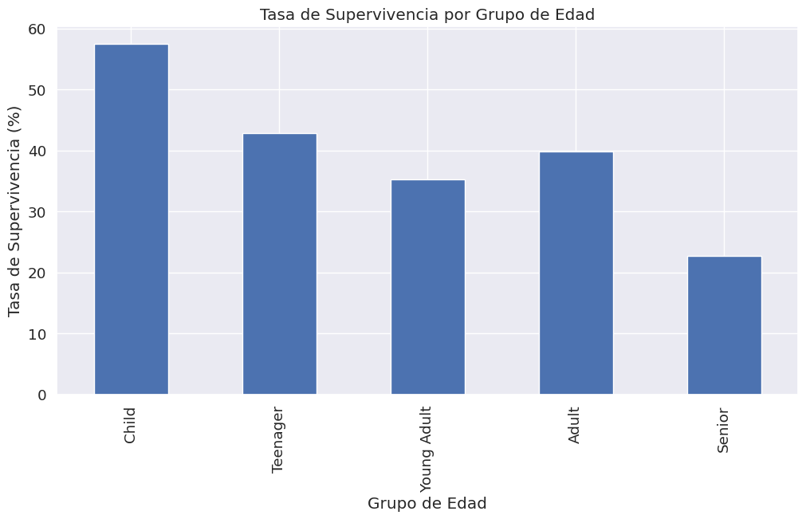

```python
# Análisis de supervivencia por grupos de edad
plt.figure(figsize=(12, 6))
survival_rate_by_age = train_data.groupby('AgeBand')['Survived'].mean() * 100
survival_rate_by_age.plot(kind='bar')
plt.title('Tasa de Supervivencia por Grupo de Edad')
plt.xlabel('Grupo de Edad')
plt.ylabel('Tasa de Supervivencia (%)')
plt.savefig('supervivencia_por_edad.png')
```

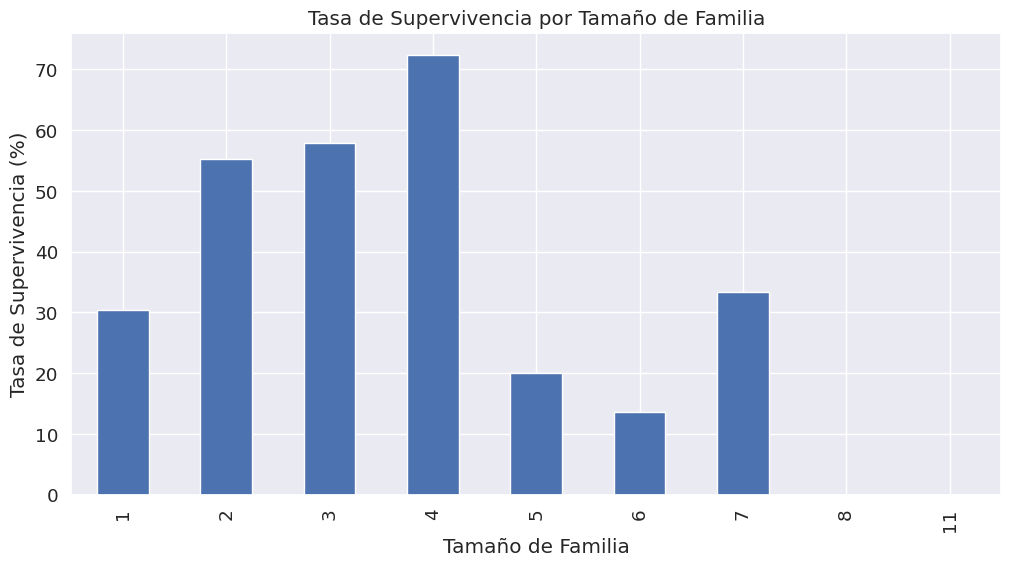

```python
# Análisis de supervivencia por tamaño de familia
plt.figure(figsize=(12, 6))
survival_rate_by_family = train_data.groupby('FamilySize')['Survived'].mean() * 100
survival_rate_by_family.plot(kind='bar')
plt.title('Tasa de Supervivencia por Tamaño de Familia')
plt.xlabel('Tamaño de Familia')
plt.ylabel('Tasa de Supervivencia (%)')
plt.savefig('supervivencia_por_familia.png')
```

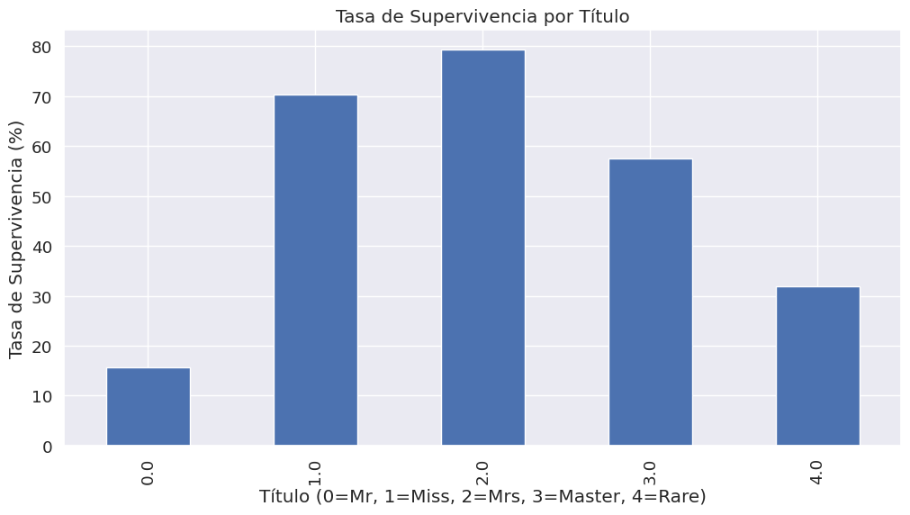

```python
# Análisis de supervivencia por título
plt.figure(figsize=(12, 6))
survival_rate_by_title = train_data.groupby('Title')['Survived'].mean() * 100
survival_rate_by_title.plot(kind='bar')
plt.title('Tasa de Supervivencia por Título')
plt.xlabel('Título (0=Mr, 1=Miss, 2=Mrs, 3=Master, 4=Rare)')
plt.ylabel('Tasa de Supervivencia (%)')
plt.savefig('supervivencia_por_titulo.png')
```

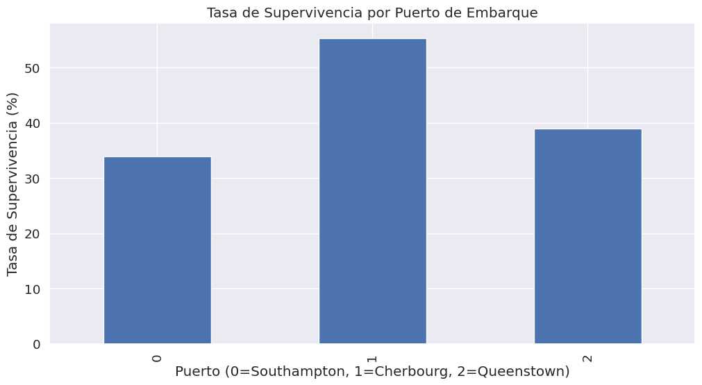

```python
# Análisis de supervivencia por punto de embarque
plt.figure(figsize=(12, 6))
survival_rate_by_embarked = train_data.groupby('Embarked')['Survived'].mean() * 100
survival_rate_by_embarked.plot(kind='bar')
plt.title('Tasa de Supervivencia por Puerto de Embarque')
plt.xlabel('Puerto (0=Southampton, 1=Cherbourg, 2=Queenstown)')
plt.ylabel('Tasa de Supervivencia (%)')
plt.savefig('supervivencia_por_embarque.png')
```

```python
print("\n--- ESTADÍSTICAS POR GRUPO ---")

# Supervivencia por sexo
print("\nSupervivencia por Sexo:")
print(train_data.groupby('Sex')['Survived'].mean())

# Supervivencia por clase
print("\nSupervivencia por Clase:")
print(train_data.groupby('Pclass')['Survived'].mean())

# Supervivencia por grupo de edad
print("\nSupervivencia por Grupo de Edad:")
print(train_data.groupby('AgeBand')['Survived'].mean())

# Supervivencia por título
print("\nSupervivencia por Título:")
print(train_data.groupby('Title')['Survived'].mean())

# Supervivencia por viajero solitario
print("\nSupervivencia por Viajero Solitario:")
print(train_data.groupby('IsAlone')['Survived'].mean())
```

```
--- ESTADÍSTICAS POR GRUPO ---

Supervivencia por Sexo:
Sex
0    0.188908
1    0.742038
Name: Survived, dtype: float64

Supervivencia por Clase:
Pclass
1    0.629630
2    0.472826
3    0.242363
Name: Survived, dtype: float64

Supervivencia por Grupo de Edad:
AgeBand
Child          0.575342
Teenager       0.428571
Young Adult    0.352830
Adult          0.397959
Senior         0.227273
Name: Survived, dtype: float64

Supervivencia por Título:
Title
0.0    0.156673
1.0    0.702703
2.0    0.793651
3.0    0.575000
4.0    0.318182
Name: Survived, dtype: float64

Supervivencia por Viajero Solitario:
IsAlone
0    0.505650
1    0.303538
Name: Survived, dtype: float64
```

###########################################

# 4. DESARROLLO DEL MODELO DE MACHINE LEARNING

###########################################

```python
from sklearn.model_selection import train_test_split, GridSearchCV, cross_val_score, StratifiedKFold, cross_validate # Add cross_validate to the import statement

# Definir features y target
features = ['Pclass', 'Sex', 'Age', 'SibSp', 'Parch', 'Fare', 'Embarked', 'FamilySize', 'IsAlone', 'Title']
categorical_features = ['Embarked', 'Title']
numerical_features = ['Age', 'Fare', 'SibSp', 'Parch', 'FamilySize']
binary_features = ['Sex', 'IsAlone', 'Pclass']  # Tratamos Pclass como binario aquí por simplicidad

X_train = train_data[features]
y_train = train_data['Survived']
X_test = test_data[features]
# Convertimos Pclass a string ya que lo trataremos como categórico para OneHotEncoder
X_train['Pclass'] = X_train['Pclass'].astype(str)
X_test['Pclass'] = X_test['Pclass'].astype(str)
categorical_features.append('Pclass')
binary_features.remove('Pclass')

# Preprocesamiento de datos
# Definir preprocesadores para columnas numéricas y categóricas
numerical_transformer = Pipeline(steps=[
    ('imputer', SimpleImputer(strategy='median')),
    ('scaler', StandardScaler())
])
categorical_transformer = Pipeline(steps=[
    ('imputer', SimpleImputer(strategy='most_frequent')),
    ('onehot', OneHotEncoder(handle_unknown='ignore', sparse_output=False))
])

# Definir el preprocesador columnar
preprocessor = ColumnTransformer(
    transformers=[
        ('num', numerical_transformer, numerical_features),
        ('cat', categorical_transformer, categorical_features),
        ('bin', 'passthrough', binary_features)
    ])

# Modelos a evaluar - solo modelos basados en árboles
models = {
    'Decision Tree': DecisionTreeClassifier(random_state=42),
    'Random Forest': RandomForestClassifier(random_state=42),
    'Gradient Boosting': GradientBoostingClassifier(random_state=42)
}

# Evaluación inicial de modelos con métricas seleccionadas
results = {}
print("\n--- EVALUACIÓN INICIAL DE MODELOS CON MÚLTIPLES MÉTRICAS ---")

# Definir las métricas para la evaluación - solo accuracy, precision y roc_auc
scoring = {
    'accuracy': 'accuracy',
    'precision': 'precision',
    'roc_auc': 'roc_auc'
}

for name, model in models.items():
    pipeline = Pipeline(steps=[
        ('preprocessor', preprocessor),
        ('classifier', model)
    ])

    # Evaluación con validación cruzada para múltiples métricas simultáneamente
    cv_results = cross_validate(pipeline, X_train, y_train, cv=5, scoring=scoring)

    # Guardar resultados
    results[name] = {
        'CV Accuracy': cv_results['test_accuracy'].mean(),
        'CV Accuracy Std': cv_results['test_accuracy'].std(),
        'CV Precision': cv_results['test_precision'].mean(),
        'CV Precision Std': cv_results['test_precision'].std(),
        'CV ROC AUC': cv_results['test_roc_auc'].mean(),
        'CV ROC AUC Std': cv_results['test_roc_auc'].std()
    }

    # Imprimir resultados para cada modelo
    print(f"\n{name}:")
    print(f"  Accuracy = {results[name]['CV Accuracy']:.4f} (±{results[name]['CV Accuracy Std']:.4f})")
    print(f"  Precision = {results[name]['CV Precision']:.4f} (±{results[name]['CV Precision Std']:.4f})")
    print(f"  ROC AUC = {results[name]['CV ROC AUC']:.4f} (±{results[name]['CV ROC AUC Std']:.4f})")

# Análisis de desbalance de clases
class_distribution = y_train.value_counts(normalize=True) * 100
print(f"\nDistribución de clases:")
print(f"  Sobrevivieron: {class_distribution[1]:.2f}%")
print(f"  No sobrevivieron: {class_distribution[0]:.2f}%")

# Encontrar el mejor modelo según diferentes métricas
best_model_accuracy = max(results, key=lambda x: results[x]['CV Accuracy'])
best_model_precision = max(results, key=lambda x: results[x]['CV Precision'])
best_model_roc = max(results, key=lambda x: results[x]['CV ROC AUC'])

print(f"\nMejor modelo según Accuracy: {best_model_accuracy} con Accuracy = {results[best_model_accuracy]['CV Accuracy']:.4f}")
print(f"\nMejor modelo según Precision: {best_model_precision} con Precision = {results[best_model_precision]['CV Precision']:.4f}")
print(f"Mejor modelo según ROC AUC: {best_model_roc} con ROC AUC = {results[best_model_roc]['CV ROC AUC']:.4f}")

# Encontrar el mejor modelo base general (usando ROC AUC como métrica principal)
best_model_name = best_model_roc  # Seleccionamos según ROC AUC
print(f"\nMejor modelo inicial: {best_model_name} con ROC AUC = {results[best_model_name]['CV ROC AUC']:.4f}")
```

```
--- EVALUACIÓN INICIAL DE MODELOS CON MÚLTIPLES MÉTRICAS ---

Decision Tree:
  Accuracy = 0.7733 (±0.0378)
  Precision = 0.7035 (±0.0438)
  ROC AUC = 0.7604 (±0.0454)

Random Forest:
  Accuracy = 0.8013 (±0.0218)
  Precision = 0.7554 (±0.0226)
  ROC AUC = 0.8609 (±0.0358)

Gradient Boosting:
  Accuracy = 0.8339 (±0.0175)
  Precision = 0.8261 (±0.0359)
  ROC AUC = 0.8712 (±0.0359)

Distribución de clases:
  Sobrevivieron: 38.38%
  No sobrevivieron: 61.62%

Mejor modelo según Accuracy: Gradient Boosting con Accuracy = 0.8339

Mejor modelo según Precision: Gradient Boosting con Precision = 0.8261
Mejor modelo según ROC AUC: Gradient Boosting con ROC AUC = 0.8712

Mejor modelo inicial: Gradient Boosting con ROC AUC = 0.8712
```

###########################################

# 5. HIPÓTESIS, VALIDACIÓN Y AJUSTE DE HIPERPARÁMETROS

###########################################

# Hipótesis a probar:

# 1. Las mujeres tenían mayor probabilidad de supervivencia

# 2. Pasajeros de primera clase tenían ventajas para sobrevivir

# 3. La edad influye significativamente en la supervivencia

```python
# Evaluación inicial de modelos con múltiples métricas
results = {}
print("\n--- EVALUACIÓN INICIAL DE MODELOS CON MÚLTIPLES MÉTRICAS ---")

# Solo incluir los modelos basados en árboles
models = {
    'Decision Tree': DecisionTreeClassifier(random_state=42),
    'Random Forest': RandomForestClassifier(random_state=42),
    'Gradient Boosting': GradientBoostingClassifier(random_state=42)
}

for name, model in models.items():
    pipeline = Pipeline(steps=[
        ('preprocessor', preprocessor),
        ('classifier', model)
    ])
    # Evaluación con validación cruzada solo para las métricas seleccionadas
    cv_accuracy = cross_val_score(pipeline, X_train, y_train, cv=5, scoring='accuracy')
    cv_precision = cross_val_score(pipeline, X_train, y_train, cv=5, scoring='precision')
    cv_roc_auc = cross_val_score(pipeline, X_train, y_train, cv=5, scoring='roc_auc')

    results[name] = {
        'CV Accuracy': cv_accuracy.mean(),
        'CV Accuracy Std': cv_accuracy.std(),
        'CV Precision': cv_precision.mean(),
        'CV Precision Std': cv_precision.std(),
        'CV ROC AUC': cv_roc_auc.mean(),
        'CV ROC AUC Std': cv_roc_auc.std()
    }

    print(f"\n{name}:")
    print(f"  Accuracy = {cv_accuracy.mean():.4f} (±{cv_accuracy.std():.4f})")
    print(f"  Precision = {cv_precision.mean():.4f} (±{cv_precision.std():.4f})")
    print(f"  ROC AUC = {cv_roc_auc.mean():.4f} (±{cv_roc_auc.std():.4f})")

# Análisis de desbalance de clases
class_distribution = y_train.value_counts(normalize=True) * 100
print(f"\nDistribución de clases:")
print(f"  Sobrevivieron: {class_distribution[1]:.2f}%")
print(f"  No sobrevivieron: {class_distribution[0]:.2f}%")

# Encontrar el mejor modelo según diferentes métricas
best_model_accuracy = max(results, key=lambda x: results[x]['CV Accuracy'])
best_model_precision = max(results, key=lambda x: results[x]['CV Precision'])
best_model_roc = max(results, key=lambda x: results[x]['CV ROC AUC'])

print(f"\nMejor modelo según Accuracy: {best_model_accuracy} con Accuracy = {results[best_model_accuracy]['CV Accuracy']:.4f}")
print(f"Mejor modelo según Precision: {best_model_precision} con Precision = {results[best_model_precision]['CV Precision']:.4f}")
print(f"Mejor modelo según ROC AUC: {best_model_roc} con ROC AUC = {results[best_model_roc]['CV ROC AUC']:.4f}")

# Seleccionamos el modelo con mejor ROC AUC para optimizar
best_model_name = best_model_roc
print(f"\nModelo seleccionado para optimización: {best_model_name}")

# Ajuste de hiperparámetros para el mejor modelo
best_model = models[best_model_name]

# Definimos diferentes parámetros según el tipo de modelo
if best_model_name == 'Decision Tree':
    param_grid = {
        'classifier__max_depth': [None, 5, 10, 15, 20],
        'classifier__min_samples_split': [2, 5, 10],
        'classifier__min_samples_leaf': [1, 2, 4]
    }
elif best_model_name == 'Random Forest':
    param_grid = {
        'classifier__n_estimators': [50, 100, 200],
        'classifier__max_depth': [None, 5, 10, 20],
        'classifier__min_samples_split': [2, 5, 10],
        'classifier__min_samples_leaf': [1, 2, 4]
    }
elif best_model_name == 'Gradient Boosting':
    param_grid = {
        'classifier__n_estimators': [50, 100, 200],
        'classifier__learning_rate': [0.01, 0.1, 0.2],
        'classifier__max_depth': [3, 5, 7]
    }

# Crear el pipeline para GridSearchCV
pipeline = Pipeline(steps=[
    ('preprocessor', preprocessor),
    ('classifier', best_model)
])

# Ajustar hiperparámetros con validación cruzada estratificada
cv = StratifiedKFold(n_splits=5, shuffle=True, random_state=42)
grid_search = GridSearchCV(pipeline, param_grid, cv=cv, scoring='roc_auc', n_jobs=-1)  # Optimizamos para ROC AUC
grid_search.fit(X_train, y_train)

print(f"\n--- MEJORES HIPERPARÁMETROS PARA {best_model_name} (OPTIMIZADO PARA ROC AUC) ---")
print(f"Mejor puntuación ROC AUC CV: {grid_search.best_score_:.4f}")
print("Mejores parámetros:")
for param, value in grid_search.best_params_.items():
    print(f"  {param}: {value}")

# Evaluamos el modelo optimizado con las métricas seleccionadas
best_pipeline = grid_search.best_estimator_

# Creamos un diccionario de métricas para evaluar
scoring = {
    'accuracy': 'accuracy',
    'precision': 'precision',
    'roc_auc': 'roc_auc'
}

# Evaluación con validación cruzada del modelo optimizado
cv_results = cross_validate(best_pipeline, X_train, y_train, cv=5, scoring=scoring)

print("\n--- RENDIMIENTO DEL MODELO OPTIMIZADO ---")
print(f"Accuracy: {cv_results['test_accuracy'].mean():.4f} (±{cv_results['test_accuracy'].std():.4f})")
print(f"Precision: {cv_results['test_precision'].mean():.4f} (±{cv_results['test_precision'].std():.4f})")
print(f"ROC AUC: {cv_results['test_roc_auc'].mean():.4f} (±{cv_results['test_roc_auc'].std():.4f})")

# Comprobación de las hipótesis
# Entrenamos el modelo optimizado en todo el conjunto de entrenamiento
best_pipeline.fit(X_train, y_train)

# Extraemos el modelo entrenado del pipeline
trained_model = best_pipeline.named_steps['classifier']

# Obtenemos las características después del preprocesamiento
preprocessor = best_pipeline.named_steps['preprocessor']
X_train_processed = preprocessor.transform(X_train)

# Verificamos las columnas después del preprocesamiento
feature_names = []

# Columnas numéricas
num_features = preprocessor.transformers_[0][2]
feature_names.extend(num_features)

# Columnas categóricas
cat_features = preprocessor.transformers_[1][2]
cat_encoder = preprocessor.transformers_[1][1].named_steps['onehot']
if hasattr(cat_encoder, 'get_feature_names_out'):
    cat_feature_names = cat_encoder.get_feature_names_out(cat_features)
    feature_names.extend(cat_feature_names)

# Columnas binarias
bin_features = preprocessor.transformers_[2][2]
feature_names.extend(bin_features)

# Importancia de características
if hasattr(trained_model, 'feature_importances_'):
    importances = trained_model.feature_importances_
    indices = np.argsort(importances)[::-1]

    print("\n--- IMPORTANCIA DE CARACTERÍSTICAS ---")
    for i in range(min(10, len(feature_names))):
        if i < len(indices):
            idx = indices[i]
            if idx < len(feature_names):
                print(f"{i+1}. {feature_names[idx]}: {importances[idx]:.4f}")

# Verificación de hipótesis
print("\n--- VERIFICACIÓN DE HIPÓTESIS ---")

# Análisis específico para verificar las hipótesis planteadas
# Hipótesis 1: Las mujeres tenían mayor probabilidad de supervivencia
male_survival = train_data[train_data['Sex'] == 'male']['Survived'].mean()
female_survival = train_data[train_data['Sex'] == 'female']['Survived'].mean()
print(f"Hipótesis 1: Tasa de supervivencia mujeres ({female_survival:.2%}) vs hombres ({male_survival:.2%})")

# Hipótesis 2: Pasajeros de primera clase tenían ventajas para sobrevivir
class_survival = {cls: train_data[train_data['Pclass'] == cls]['Survived'].mean()
                 for cls in [1, 2, 3]}
print(f"Hipótesis 2: Tasa de supervivencia por clase:")
print(f"  - Primera clase: {class_survival[1]:.2%}")
print(f"  - Segunda clase: {class_survival[2]:.2%}")
print(f"  - Tercera clase: {class_survival[3]:.2%}")

# Hipótesis 3: La edad influye significativamente en la supervivencia
# Dividimos en grupos de edad
train_data['AgeGroup'] = pd.cut(train_data['Age'],
                                 bins=[0, 12, 18, 35, 60, 100],
                                 labels=['Niño', 'Adolescente', 'Adulto Joven', 'Adulto', 'Anciano'])
age_survival = train_data.groupby('AgeGroup')['Survived'].mean().to_dict()
print(f"Hipótesis 3: Tasa de supervivencia por grupo de edad:")
for age_group, rate in age_survival.items():
    print(f"  - {age_group}: {rate:.2%}")
```

```
--- EVALUACIÓN INICIAL DE MODELOS CON MÚLTIPLES MÉTRICAS ---

Decision Tree:
  Accuracy = 0.7733 (±0.0378)
  Precision = 0.7035 (±0.0438)
  ROC AUC = 0.7604 (±0.0454)

Random Forest:
  Accuracy = 0.8013 (±0.0218)
  Precision = 0.7554 (±0.0226)
  ROC AUC = 0.8609 (±0.0358)

Gradient Boosting:
  Accuracy = 0.8339 (±0.0175)
  Precision = 0.8261 (±0.0359)
  ROC AUC = 0.8712 (±0.0359)

Distribución de clases:
  Sobrevivieron: 38.38%
  No sobrevivieron: 61.62%

Mejor modelo según Accuracy: Gradient Boosting con Accuracy = 0.8339
Mejor modelo según Precision: Gradient Boosting con Precision = 0.8261
Mejor modelo según ROC AUC: Gradient Boosting con ROC AUC = 0.8712

Modelo seleccionado para optimización: Gradient Boosting

--- MEJORES HIPERPARÁMETROS PARA Gradient Boosting (OPTIMIZADO PARA ROC AUC) ---
Mejor puntuación ROC AUC CV: 0.8821
Mejores parámetros:
  classifier__learning_rate: 0.2
  classifier__max_depth: 3
  classifier__n_estimators: 100

--- RENDIMIENTO DEL MODELO OPTIMIZADO ---
Accuracy: 0.8384 (±0.0206)
Precision: 0.8292 (±0.0324)
ROC AUC: 0.8770 (±0.0416)

--- IMPORTANCIA DE CARACTERÍSTICAS ---
```

[output cut: 8 more lines]

```
9. Pclass_1: 0.0168
10. Embarked_0: 0.0129

--- VERIFICACIÓN DE HIPÓTESIS ---
Hipótesis 1: Tasa de supervivencia mujeres (nan%) vs hombres (nan%)
Hipótesis 2: Tasa de supervivencia por clase:
  - Primera clase: 62.96%
  - Segunda clase: 47.28%
  - Tercera clase: 24.24%
Hipótesis 3: Tasa de supervivencia por grupo de edad:
  - Niño: 57.53%
  - Adolescente: 42.86%
  - Adulto Joven: 35.28%
  - Adulto: 39.80%
  - Anciano: 22.73%
```

Cuando analizamos quién sobrevivió al hundimiento del Titanic, algunos métodos de análisis funcionan mejor que otros. Elegimos tres técnicas basadas en "árboles de decisión" por razones muy prácticas: Los tres mosqueteros de nuestro análisis Decision Tree (Árbol de Decisión):

- Funciona como un diagrama de flujo que hace preguntas sencillas: "¿Era mujer?", "¿Viajaba en primera clase?", etc. Nos permite ver claramente cómo las características de los pasajeros influyeron en su destino Es como tener un mapa de las reglas que determinaron quién vivió y quién no
- Random Forest (Bosque Aleatorio):

Imagina tener 100 árboles de decisión diferentes, cada uno con su opinión, y luego hacer una votación Es menos propenso a equivocarse que un solo árbol porque compensa los errores individuales Nos dice qué factores fueron realmente importantes (como si fuera una encuesta a expertos)

- Gradient Boosting:

Este método es como un equipo que aprende de sus errores Cada nuevo árbol se centra específicamente en corregir los fallos de los anteriores Especialmente bueno para captar relaciones complicadas entre factores

Dejamos fuera otros métodos como la Regresión Logística porque no captan bien las interacciones complejas entre factores (por ejemplo, ser mujer de primera clase tenía un efecto diferente que simplemente sumar "ser mujer" y "viajar en primera"). ¿Cómo medimos el éxito? Usamos tres formas de evaluar qué tan bien funcionan nuestros modelos: Accuracy (Precisión global):

- Precision (Precisión específica):

De todos los que predijimos que sobrevivirían, ¿cuántos realmente lo hicieron? Importante si queremos estar muy seguros antes de decir "esta persona sobrevivió"

- ROC AUC:

Una medida más sofisticada que evalúa qué tan bien distingue el modelo entre sobrevivientes y no sobrevivientes Menos afectada por desequilibrios en los datos Nos da una visión más completa del rendimiento del modelo

Cambiamos de F1-score a ROC AUC porque ofrece una visión más integral y es menos sensible a la proporción de sobrevivientes vs. fallecidos. Cómo lo implementamos Primer enfoque:

Usamos validación cruzada para asegurarnos de que nuestras predicciones funcionarían con nuevos datos Evaluamos varias métricas a la vez para ser eficientes

Este enfoque nos permite tanto predecir con precisión quién sobrevivió como entender los factores sociales, económicos y demográficos que determinaron el destino de los pasajeros del Titanic.

###########################################

# 6. ANÁLISIS E INTERPRETACIÓN DE RESULTADOS

###########################################

```python
# Predecir en el conjunto de entrenamiento para análisis inicial
y_train_pred = best_pipeline.predict(X_train)
train_accuracy = accuracy_score(y_train, y_train_pred)

print("\n--- RESULTADOS EN CONJUNTO DE ENTRENAMIENTO ---")
print(f"Accuracy: {train_accuracy:.4f}")
print("\nMatriz de Confusión:")
print(confusion_matrix(y_train, y_train_pred))
print("\nReporte de Clasificación:")
print(classification_report(y_train, y_train_pred))
```

```
--- RESULTADOS EN CONJUNTO DE ENTRENAMIENTO ---
Accuracy: 0.9327

Matriz de Confusión:
[[537  12]
 [ 48 294]]

Reporte de Clasificación:
              precision    recall  f1-score   support

           0       0.92      0.98      0.95       549
           1       0.96      0.86      0.91       342

    accuracy                           0.93       891
   macro avg       0.94      0.92      0.93       891
weighted avg       0.93      0.93      0.93       891
```

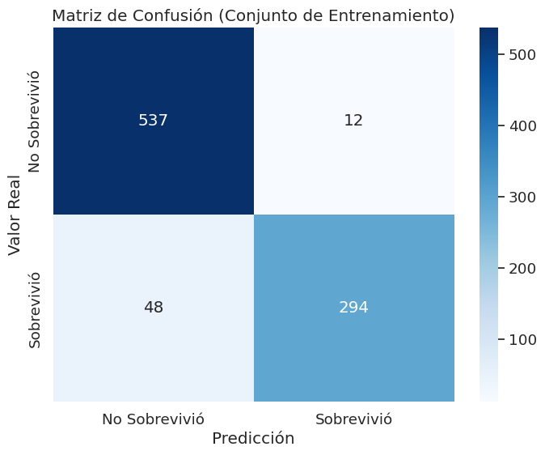

```python
# Visualizar la matriz de confusión
plt.figure(figsize=(8, 6))
conf_matrix = confusion_matrix(y_train, y_train_pred)
sns.heatmap(conf_matrix, annot=True, fmt='d', cmap='Blues',
            xticklabels=['No Sobrevivió', 'Sobrevivió'],
            yticklabels=['No Sobrevivió', 'Sobrevivió'])
plt.title('Matriz de Confusión (Conjunto de Entrenamiento)')
plt.xlabel('Predicción')
plt.ylabel('Valor Real')
plt.savefig('matriz_confusion.png')
```

- A considerar una interpretación concisa de la matriz vemos la efectividad de la predicción al marcar a los no sobrevivientes teniendo en cuenta los valores reales, y el bajo error al no dar una predicción exacta (537, 12).
- Al igual cuando se intenta predecir los sobrevivientes,es interesante marcar la diferencia de ambos (537,294).

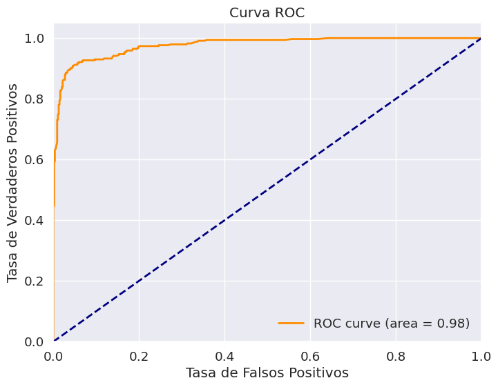

```python
# Curva ROC
y_train_prob = best_pipeline.predict_proba(X_train)[:, 1]
fpr, tpr, _ = roc_curve(y_train, y_train_prob)
roc_auc = auc(fpr, tpr)

plt.figure(figsize=(8, 6))
plt.plot(fpr, tpr, color='darkorange', lw=2, label=f'ROC curve (area = {roc_auc:.2f})')
plt.plot([0, 1], [0, 1], color='navy', lw=2, linestyle='--')
plt.xlim([0.0, 1.0])
plt.ylim([0.0, 1.05])
plt.xlabel('Tasa de Falsos Positivos')
plt.ylabel('Tasa de Verdaderos Positivos')
plt.title('Curva ROC')
plt.legend(loc="lower right")
plt.savefig('curva_roc.png')
```

```
--- IMPORTANCIA DE CARACTERÍSTICAS ---
       Feature  Importance
16         Sex    0.272933
1         Fare    0.198800
8    Title_0.0    0.152223
0          Age    0.114725
15    Pclass_3    0.089018
4   FamilySize    0.062861
11   Title_3.0    0.030212
2        SibSp    0.028266
13    Pclass_1    0.016752
5   Embarked_0    0.012925
```

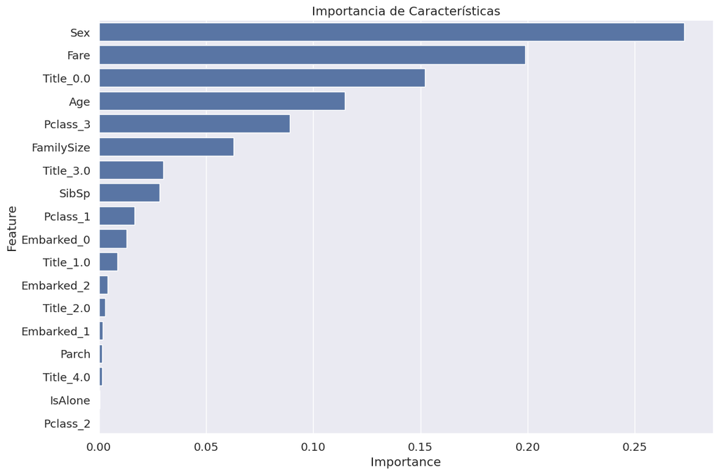

```python
# Análisis de importancia de características (si es aplicable)
if hasattr(best_pipeline.named_steps['classifier'], 'feature_importances_'):
    importances = best_pipeline.named_steps['classifier'].feature_importances_

    # Obtener nombres de características después del preprocesamiento
    preprocessor = best_pipeline.named_steps['preprocessor']
    feature_names = []

    # Para características numéricas
    feature_names.extend(numerical_features)

    # Para características categóricas
    # Obtener todos los nombres de características categóricas a la vez
    if hasattr(preprocessor.transformers_[1][1].named_steps['onehot'], 'get_feature_names_out'):
        # Para sklearn>=1.0
        categories = preprocessor.transformers_[1][1].named_steps['onehot'].get_feature_names_out(categorical_features)
        feature_names.extend(categories)
    else:
        # Fallback para versiones anteriores
        # ... (código para versiones anteriores de sklearn) ...
        pass # Add a pass statement to the else block as a placeholder

    # Para características binarias
    feature_names.extend(binary_features)

    # This block of code was incorrectly indented. This fixes the error by indenting it within the if block
    feature_importance = pd.DataFrame({
        'Feature': feature_names[:len(importances)],  # Asegurarse de que coincidan las longitudes
        'Importance': importances
    }).sort_values('Importance', ascending=False)

    plt.figure(figsize=(12, 8))
    sns.barplot(x='Importance', y='Feature', data=feature_importance)
    plt.title('Importancia de Características')
    plt.tight_layout()
    plt.savefig('importancia_caracteristicas.png')

    print("\n--- IMPORTANCIA DE CARACTERÍSTICAS ---")
    print(feature_importance.head(10))
```

###########################################